# Faithful Model Explanations

Counterfactual Explanations and Predictive Uncertainty for Trustworthy Machine Learning

Patrick Altmeyer

Delft University of Technology

Delft University of Technology

[**Patrick Altmeyer**](https://www.patalt.org/)

Arie van Deursen

Cynthia C. S. Liem

November 4, 2026

## Quick Introduction

- Recently entered the 3rd year of my PhD in Trustworthy Artificial Intelligence at Delft University of Technology.
- Previously, educational background in Economics and Finance and two years in Monetary Policy at the Bank of England.
- Interested in applying Trustworthy AI to real-world problems, particularly in the financial sector.

# Background

## Counterfactual Explanations

> Born out of the [need for explanations](https://www.turing.ac.uk/research/impact-stories/a-right-to-explanation) …

**Counterfactual Explanation** (CE) explain how inputs into a model need to change for it to produce different outputs (Wachter et al. 2017).

Provided the changes are realistic and actionable, they can be used for **Algorithmic Recourse** (AR) to help individuals who face adverse outcomes.

## Example: Consumer Credit

From ‘loan denied’ to ‘loan supplied’: [`CounterfactualExplanations.jl`](https://github.com/JuliaTrustworthyAI/CounterfactualExplanations.jl) 📦.

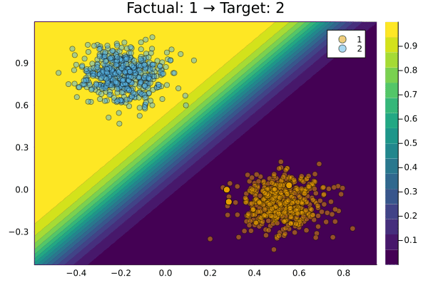

Figure 1: Gradient-based counterfactual search.

[figure not shown]

Figure 2: Counterfactuals for Give Me Some Credit dataset (Kaggle 2011).

## Example: Insurance Premium<sup>1</sup>

- **Input** $\mathbf{X}$: A dataset of individuals containing demographic and financial information.
- **Additional Input** $\mathbf{Z}$: Individuals can opt-in to provide their personal Apple Health data to improve their chance of receiving a lower premium.
- **Binary output** $\mathbf{Y}$: based on the data, the individual is either eligible ($y=1$) or not eligible ($y=0$) for a lower premium.
- To model $p(y=1|X)$ the insurance provider can rely on an interpretable linear classifier.
- To model $p(y=1|X,Z)$ the insurance provider turns to a more accurate but less interpretable black-box model.
[^1]: For simplicity, we’ll stay in the classification setting. Work on counterfactual regression like Spooner et al. (2021) exists but it is scarce.

## Example: Insurance Premium

In the EU, individuals have the right “[…] to *obtain* an explanation of the decision reached after such assessment and to challenge the decision.” ([Recital 71 of the General Data Protection Regulation (GDPR)](https://gdpr-info.eu/recitals/no-71/))

> In our example, who do you think is most likely to ask for an explanation?

# You were promised some maths … 🌶️🌶️🌶️

## Gradient-based Counterfactual Search

The starting point for most counterfactual generators is as follows,

$$\begin{aligned}
\mathbf{Z}^\prime =& \arg \min_{\mathbf{Z}^\prime \in \mathcal{Z}^L} \{ {\text{yloss}(M_{\theta}(f(\mathbf{Z}^\prime)),\mathbf{y}^+)} \\ &+ \lambda {\text{cost}(f(\mathbf{Z}^\prime)) } \}
\end{aligned}
\tag{1}$$

where $\mathbf{Z}^\prime$ is a counterfactual, $M_{\theta}$ is the black-box model and $\mathbf{y}^+$ is the desired output.

## But wait a second …

Equation 1 looks a lot like an adversarial attack (Goodfellow et al. 2015), doesn’t it?

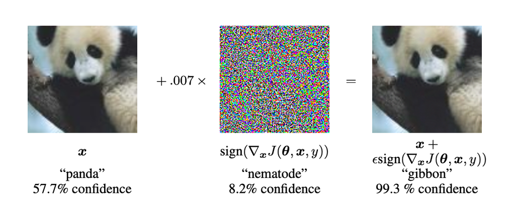

Figure 3: Adversarial attack on an Image Classifier.

In both settings, we take gradients with respect to features $\nabla_{\mathbf{Z}^\prime}\text{yloss}(M_{\theta}(f(\mathbf{Z}^\prime)),\mathbf{y}^+)$ in order to trigger changes in the model’s output.

## Gradient Descend Visualized

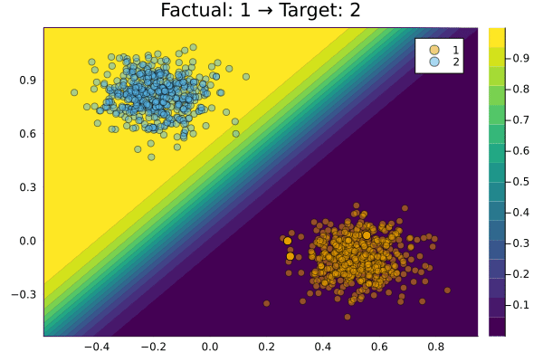

Figure 4: Gradient-based counterfactual search.

# Our Research

## Open Questions

1. What makes a counterfactual **plausible**?
2. Why do we need plausibility?
3. Is plausibility all we need?
4. What makes models more **explainable**?

## Plausibility

There’s no consensus on the exact definition of plausibility but we think about it as follows:

**Definition 1 (Plausible Counterfactuals)** Let $\mathcal{X}|\mathbf{y}^+= p(\mathbf{x}|\mathbf{y}^+)$ denote the true conditional distribution of samples in the target class $\mathbf{y}^+$. Then for $\mathbf{x}^{\prime}$ to be considered a plausible counterfactual, we need: $\mathbf{x}^{\prime} \sim \mathcal{X}|\mathbf{y}^+$.

## Counter Example

- The counterfactual in Figure 5 is valid: it has crossed the decision boundary.
- But is it consistent with the data in the target class (blue)?

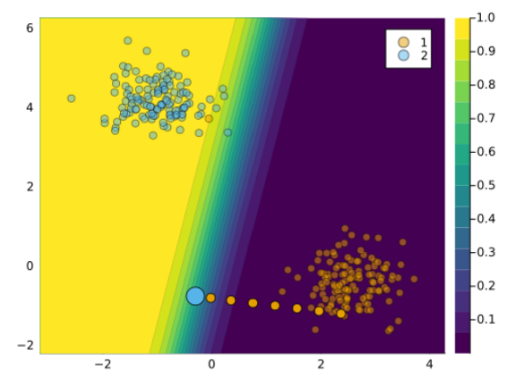

Figure 5: A valid but implausible counterfactual. Source: Altmeyer, Deursen, et al. (2023)

## Why Plausibility?

- Actionability: If a counterfactual is implausible, it is unlikely to be actionable.
- Fairness: If a counterfactual is implausible, it is unlikely to be fair.
- Robustness: If a counterfactual is implausible, it is unlikely to be robust.

**But**: Higher plausibility seems to require larger changes and hence increase costs to individuals.

## Recourse Dynamics

Moving just across the decision boundary may minimize costs to individuals but it may also generate external costs for other stakeholders (Altmeyer, Angela, et al. 2023).

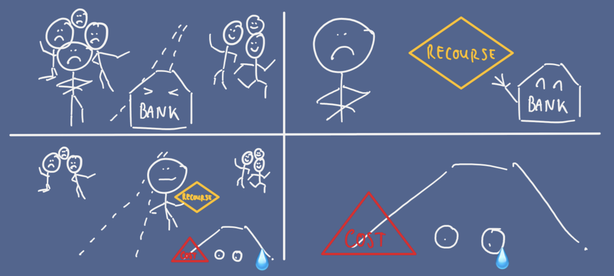

## A Balancing Act

- Minimizing **private** costs generates **external** costs for other stakeholders.
- To avoid this, counterfactuals need to be **plausible**, i.e. comply with the data-generating process.
- In practice, costs to various stakeholders need to be carefully **balanced**.

> Is plausibility really all we need?

## Pick your Poison?

All of these counterfactuals are valid explanations for the model’s prediction. Which one would you pick?

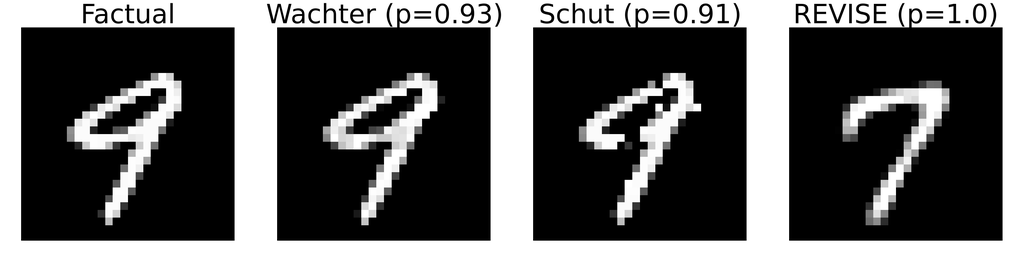

Figure 6: Turning a 9 into a 7: Counterfactual Examplanations for an Image Classifier.

## What do Models Learn?

These images are sampled from the posterior distribution learned by the model. Looks different, no?

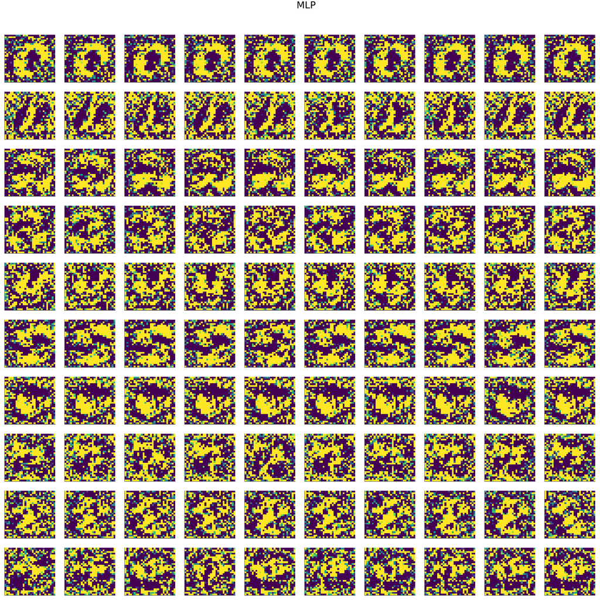

Figure 7: Conditional Generated Images from the Image Classifier

## Faithful Counterfactuals

We propose a way to generate counterfactuals that are as plausible as the underlying model permits (under review).

**Definition 2 (Faithful Counterfactuals)** Let $\mathcal{X}_{\theta}|\mathbf{y}^+ = p_{\theta}(\mathbf{x}|\mathbf{y}^+)$ denote the conditional distribution of $\mathbf{x}$ in the target class $\mathbf{y}^+$, where $\theta$ denotes the parameters of model $M_{\theta}$. Then for $\mathbf{x}^{\prime}$ to be considered a faithful counterfactual, we need: $\mathbf{x}^{\prime} \sim \mathcal{X}_{\theta}|\mathbf{y}^+$.

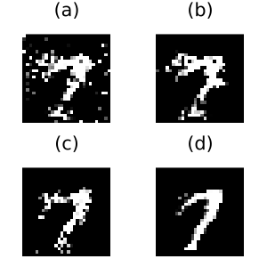

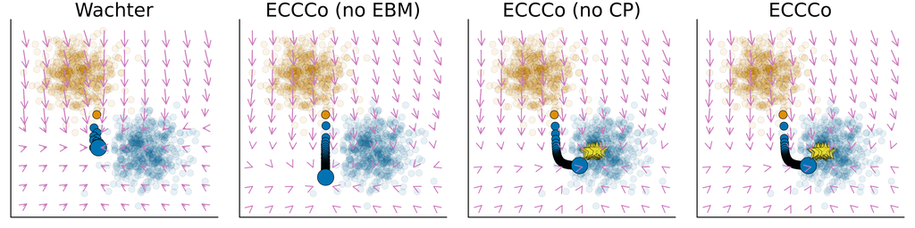

Figure 8: Gradient fields and counterfactual paths for different generators.

## Improving Models

Now that we have a tool to faithfully explain models we may ask: **how** do models learn plausible explanations? Initial evidence:

1. Incorporating predictive uncertainty (e.g. ensembling).
2. Addressing robustness (e.g. adversarial training in Schut et al. (2021)).
3. Better model architectures.
4. Hybrid modelling (i.e. combining generative and discriminative models).

## Example: Architecture

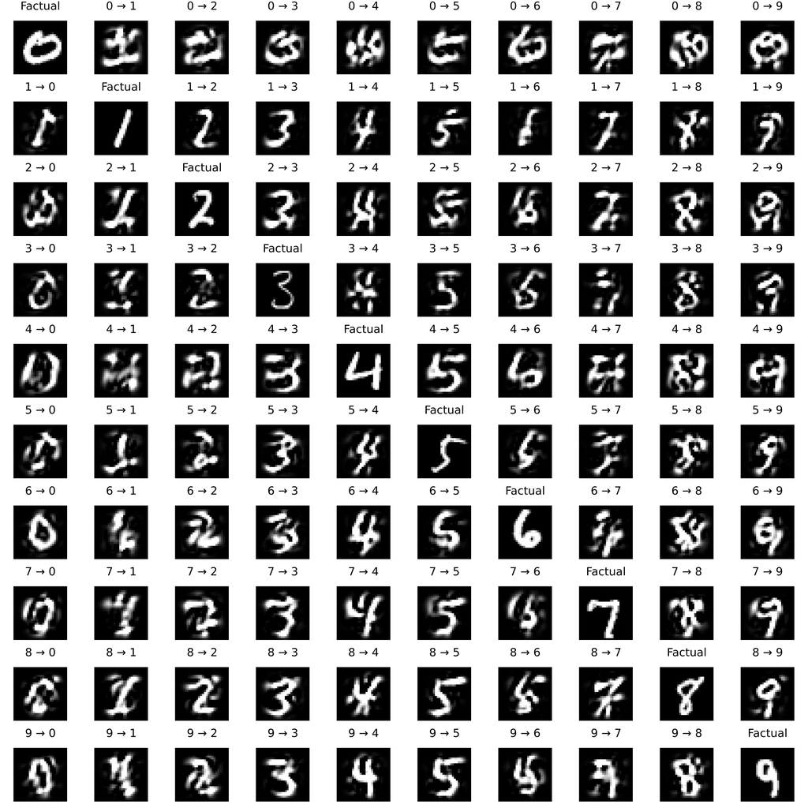

Figure 9: Counterfactuals for LeNet-5 convolutional neural network (LeCun et al. 1998).

## Example: JEM Ensemble

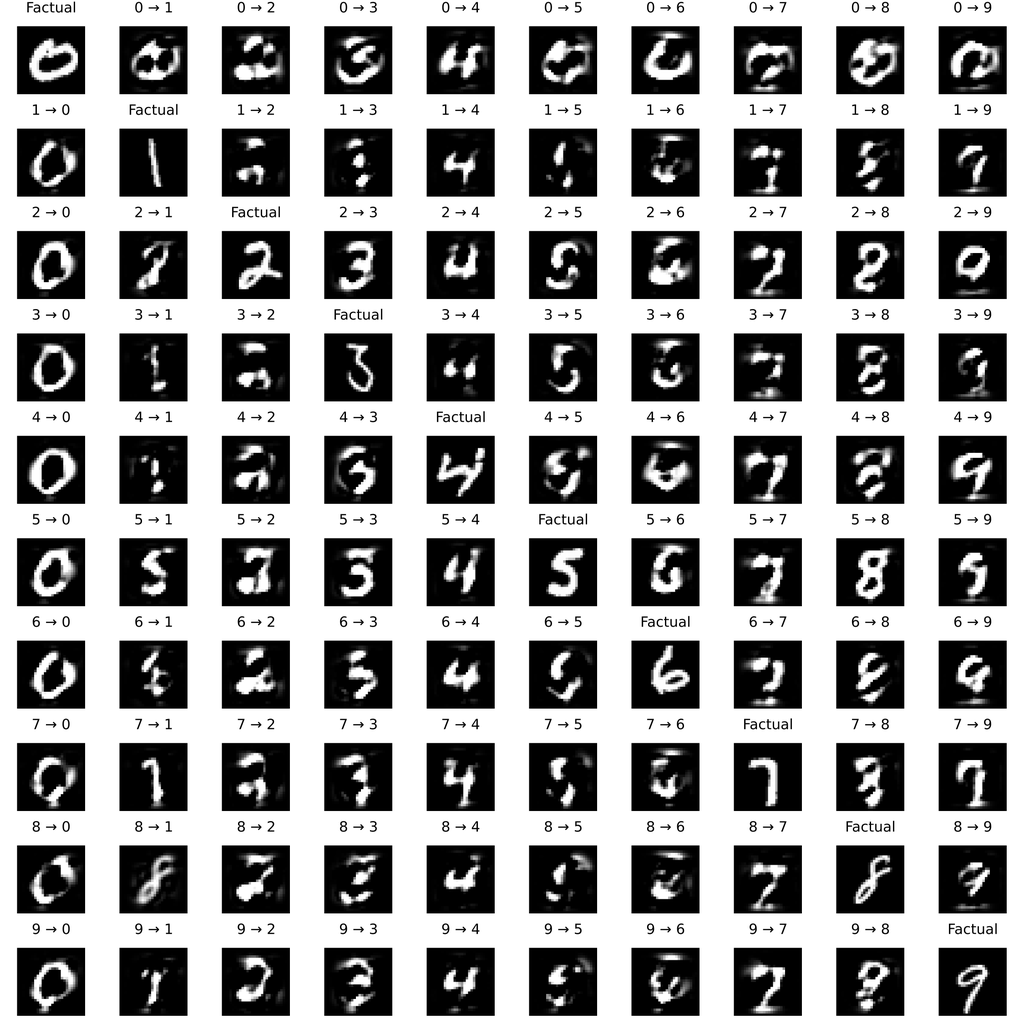

Figure 10: Counterfactuals for an ensemble of Joint Energy Models (JEM) (Grathwohl et al. 2020).

# Our Open-Source Work in `Julia`

## 🐶 Taija

> Research informs development, development informs research.

[figure not shown]

Trustworthy Artificial Intelligence in Julia.

[Taija](https://github.com/JuliaTrustworthyAI) is a collection of open-source packages for Trustworthy AI in Julia. Our goal is to help researchers and practitioners assess the trustworthiness of predictive models.

Our work has been presented online for JuliaCon 2022, at MIT in Boston for JuliaCon 2023 and hopefully beyond.

## Counterfactual Explanations

All the work presented today is powered by [`CounterfactualExplanations.jl`](https://github.com/JuliaTrustworthyAI/CounterfactualExplanations.jl) 📦.

There is also a corresponding paper, [*Explaining Black-Box Models through Counterfactuals*](https://proceedings.juliacon.org/papers/10.21105/jcon.00130), which has been published in JuliaCon Proceedings.

If you decide to use this package in your work, please consider citing the paper:

[figure not shown]

## Conformal Prediction

Conformal Prediction is a model-agnostic, distribution-free approach to Predictive Uncertainty Quantification: [`ConformalPrediction.jl`](https://github.com/JuliaTrustworthyAI/ConformalPrediction.jl) 📦.

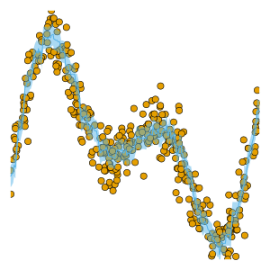

Figure 11: Conformal Prediction intervals for regression.

[figure not shown]

Figure 12: Conformal Prediction sets for an Image Classifier.

## Laplace Redux

Effortless Bayesian Deep Learning through Laplace Approximation Daxberger et al. (2021): [`LaplaceRedux.jl`](https://github.com/JuliaTrustworthyAI/LaplaceRedux.jl) 📦.

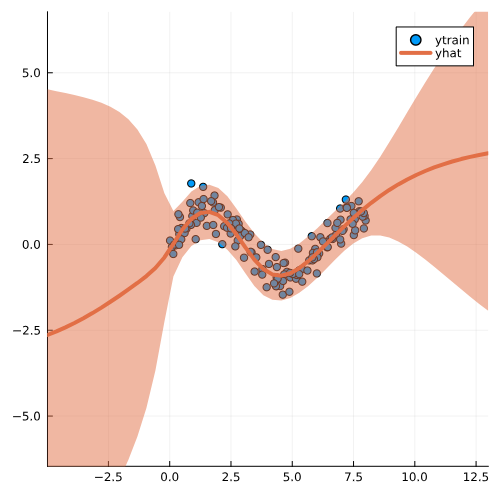

Figure 13: Predictive interval for neural network with Laplace Approximation.

## Joint Energy Models

Joint Energy Models (JEMs) are hybrid models trained to learn the conditional output **and** input distribution (Grathwohl et al. 2020): [`JointEnergyModels.jl`](https://github.com/JuliaTrustworthyAI/JointEnergyModels.jl) 📦.

[figure not shown]

Figure 14: A JEM trained on Circles data.

## Questions?

Includes joint work with Cynthia C. S. Liem, Arie van Deursen, Mojtaba Farmanbar, Aleksander Buszydlik, Karol Dobiczek, Giovan Angela and many other students at TU Delft.

Slides power by [Quarto](https://quarto.org/).

## References

Altmeyer, Patrick, Giovan Angela, Aleksander Buszydlik, Karol Dobiczek, Arie van Deursen, and Cynthia C. S. Liem. 2023. “Endogenous Macrodynamics in Algorithmic Recourse.” *2023 IEEE Conference on Secure and Trustworthy Machine Learning (SaTML)*, 418–31. https://doi.org/10.1109/satml54575.2023.00036.

Altmeyer, Patrick, Arie van Deursen, and Cynthia C. S. Liem. 2023. “Explaining Black-Box Models through Counterfactuals.” *Proceedings of the JuliaCon Conferences* 1: 130. https://doi.org/10.21105/jcon.00130.

Daxberger, Erik, Agustinus Kristiadi, Alexander Immer, Runa Eschenhagen, Matthias Bauer, and Philipp Hennig. 2021. “Laplace Redux-Effortless Bayesian Deep Learning.” *Advances in Neural Information Processing Systems* 34.

Goodfellow, Ian, Jonathon Shlens, and Christian Szegedy. 2015. *Explaining and Harnessing Adversarial Examples*. https://arxiv.org/abs/1412.6572.

Grathwohl, Will, Kuan-Chieh Wang, Joern-Henrik Jacobsen, David Duvenaud, Mohammad Norouzi, and Kevin Swersky. 2020. “Your Classifier Is Secretly an Energy Based Model and You Should Treat It Like One.” *International Conference on Learning Representations*.

Immer, Alexander, Maciej Korzepa, and Matthias Bauer. 2020. “Improving Predictions of Bayesian Neural Networks via Local Linearization.” https://arxiv.org/abs/2008.08400.

Kaggle. 2011. *Give Me Some Credit, Improve on the State of the Art in Credit Scoring by Predicting the Probability That Somebody Will Experience Financial Distress in the Next Two Years.* Https://www.kaggle.com/c/GiveMeSomeCredit; Kaggle. https://www.kaggle.com/c/GiveMeSomeCredit.

LeCun, Yann, Léon Bottou, Yoshua Bengio, and Patrick Haffner. 1998. “Gradient-Based Learning Applied to Document Recognition.” *Proceedings of the IEEE* 86 (11): 2278–324.

Schut, Lisa, Oscar Key, Rory McGrath, et al. 2021. “Generating Interpretable Counterfactual Explanations By Implicit Minimisation of Epistemic and Aleatoric Uncertainties.” *International Conference on Artificial Intelligence and Statistics*, 1756–64.

Spooner, Thomas, Danial Dervovic, Jason Long, Jon Shepard, Jiahao Chen, and Daniele Magazzeni. 2021. *Counterfactual Explanations for Arbitrary Regression Models*. https://arxiv.org/abs/2106.15212.

Wachter, Sandra, Brent Mittelstadt, and Chris Russell. 2017. “Counterfactual Explanations Without Opening the Black Box: Automated Decisions and the GDPR.” *Harv. JL & Tech.* 31: 841. https://doi.org/10.2139/ssrn.3063289.